# Table of Contents

## Plot the data

Different types of plots that helps to identify outliers:

- Box plot
- Scatter plot
- Distribution plot (histogram)
- Moving average of the time-series etc.

Below are some utility functions to assist in plotting different charts.

```python
def get_color(column):
    """
    Get color for plot depending upon column name
    """
    return 'lightcoral' if column == 'Signal' else 'dodgerblue'

def get_colors(column):
    """
    Get pair of colors depending upon column name
    """
    return ('lightcoral', 'maroon') if column == 'Signal' else ('dodgerblue', 'blue')


def scatter_plot(x, y, ax):
    """
    Scatter plot between signal and close price
    """
    ax.scatter(x=x, y=y, marker='o', color='sandybrown', edgecolor='black')
    ax.set(title='Scatter Plot of Signal vs ClosePrice',
           xlabel='Signal',
           ylabel='ClosePrice')

def add_legend(ax):
    """
    Add legend to given axes
    """
    leg = ax.legend(loc='best', frameon=True, framealpha=1)
    leg.get_frame().set_edgecolor('black')


def cross_correlation_plot(df, x, y, ax):
    """
    Cross-correlation plot
    """
    xseries = df[x]
    yseries = df[y]

    # Calculates lags and correlation values
    lags, c, line, b = ax.xcorr(xseries, yseries, usevlines=True, maxlags=50, normed=True, lw=2)

    # Identify lag with max correlation value
    # and highlight that point
    max_val_idx = c.argmax()
    ax.axvline(x=lags[max_val_idx], color='lime', linestyle='-',
               label=f'Max correlation = {c[max_val_idx].round(2)} at Lag = {lags[max_val_idx]} of {x}')

    ax.set(title='Cross-correlation between Signal and ClosePrice',
           xlabel='Lags',
           ylabel='Pearson correlation')

    add_legend(ax)


def rolling_correlation_plot(df, ax, sma_days=[10, 21]):
    """
    Rolling correlation plot
    """
    for days in sma_days:
        rolling_corr_df = df['Signal'].rolling(window=days, center=True).corr(df['ClosePrice'])
        rolling_corr_df.plot(ax=ax, label=f'{days}-Day Rolling Pearson Correlation')

    ax.set(title='Rolling Pearson Correlation between Signal and ClosePrice [{0}]'.format(", ".join(['{0} days'.format(str(x)) for x in sma_days])),
           xlabel='Date',
           ylabel='Correlation')
    add_legend(ax)


def line_plot(df, column, ax, sma_days=10):
    """
    Line plot for given time series
    """
    color1, color2 = get_colors(column)
    series = df[column]
    series.plot(ax=ax, color=color1, label=f'{column}')
    series.rolling(sma_days).mean().plot(ax=ax, color=color2, alpha=0.7, label=f'{column} {sma_days}-day Moving Average')
    ax.set(title=f'{column} time series',
           xlabel='Date',
           ylabel=f'{column}')
    add_legend(ax)


def distribution_plot(df, column, ax):
    """
    Distribution plot
    """
    color = get_color(column)
    series = df[column]
    sns.distplot(series, color=color, ax=ax,
                 hist_kws=dict(edgecolor="k", linewidth=2),
                 bins=30, hist=True, label=f'{column}')

    ax.set_title(f'Distribution of {column}')
    add_legend(ax)


def box_plot(df, column, ax):
    """
    Box plot
    """
    series = df[column]
    color = get_color(column)
    sns.boxplot(series, color=color, ax=ax)
    ax.set(title=f'Box plot for {column}')
```

```python
def plots_for_outliers(df):
    """
    Useful plots for checking outliers time-series data
    """
    signal = df['Signal']
    close_price = df['ClosePrice']

    grid = gridspec.GridSpec(nrows=5, ncols=2)

    fig = plt.figure(figsize=(15, 15))
    fig.clf()

    # Add axes which can span multiple grid boxes
    ax1 = fig.add_subplot(grid[0, :])
    ax2 = fig.add_subplot(grid[1, 0])
    ax3 = fig.add_subplot(grid[1, 1])
    ax4 = fig.add_subplot(grid[2, 0])
    ax5 = fig.add_subplot(grid[2, 1])
    ax6 = fig.add_subplot(grid[3, 0])
    ax7 = fig.add_subplot(grid[3, 1])

    # Scatter plot
    scatter_plot(x=signal, y=close_price, ax=ax1)

    # Time series plots
    line_plot(df, column='Signal', ax=ax2, sma_days=10)
    line_plot(df, column='ClosePrice', ax=ax3, sma_days=10)

    # Distribution plots
    distribution_plot(df, column='Signal', ax=ax4)
    distribution_plot(df, column='ClosePrice', ax=ax5)

    # Box plots
    box_plot(df, column='Signal', ax=ax6)
    box_plot(df, column='ClosePrice', ax=ax7)

    fig.tight_layout()
    plt.show()
```

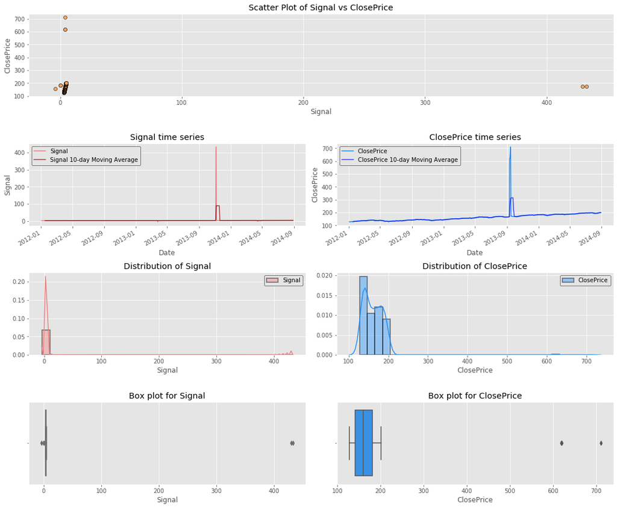

```python
plots_for_outliers(data)
```

> **Comment:**
> - Scatter plot clearly shows the presence of outliers (both for `Signal` and `ClosePrice`)
> - Individual time-series plots also shows a big spike due to these outliers.
> - Box plot also confirms the presence of outliers (highlighted as dots)
> - Next step would be to identify and fix these outlier values (either filling them with appropriate value or removing them altogether from the data)

## Identify Outliers

There are multiple ways to identify outliers given a dataset. Few of the these include:

1. Z-score: Z-scores are the number of standard deviations above and below the mean that each value falls
2. Modified Z-score: More robust than Z-score since it relies on median (and not mean) to detect outliers, so less influenced by outliers compared to traditional Z-score
3. Interquartile range: Measure of statistical dispersion, equal to the difference between 75th and 25th percentiles or between upper and lower quartiles

```python
def get_numpy_array(series):
    """
    Convert a series to numpy.array
    """
    if not isinstance(series, np.ndarray):
        series = np.array(series)
    return series

def get_zscore(series):
    """
    Get Z-score using scipy.stats method
    """
    return np.abs(stats.zscore(series))


def get_outliers_using_zscore(series, threshold=3):
    """
    Identify the outliers using Z-score method
    """
    series = get_numpy_array(series)
    z_score = get_zscore(series)
    return series[np.where(z_score > threshold)]


def get_outliers_using_modified_zscore(series, threshold=3.5):
    """
    Identify the outliers using modified Z-score method.
    Overcome the limitations of Z-score method.
    """
    series = get_numpy_array(series)
    median = np.median(series)
    median_absolute_deviation = np.median([np.abs(val - median) for val in series])
    modified_z_scores = [0.6745 * (val - median) / median_absolute_deviation for val in series]
    return series[np.where(np.abs(modified_z_scores) > threshold)]


def get_iqr_range(series):
    """
    Get Interquartile range for given series
    """
    series = get_numpy_array(series)
    q1, q3 = np.percentile(series, [25, 75])
    iqr = q3 - q1
    lower_bound = q1 - (1.5 * iqr)
    upper_bound = q3 + (1.5 * iqr)
    return lower_bound, upper_bound


def get_outliers_using_iqr(series):
    """
    Identify the outliers using interquartile range (IQR)
    """
    series = get_numpy_array(series)
    lbound, ubound = get_iqr_range(series)
    return [x for x in series if x < lbound or x > ubound]
```

```python
def print_outliers(method, column):
    """
    Print outliers identified using given method and for given column of data.
    """
    if method == 'zscore':
        outliers = get_outliers_using_zscore(data[column])
    elif method == 'modified_zscore':
        outliers = get_outliers_using_modified_zscore(data[column])
    elif method == 'iqr':
        outliers = get_outliers_using_iqr(data[column])
    else:
        raise ValueError("Incorrect method value. Valid values: [zscore, modified_zscore, iqr]")

    print("\n{0} Outliers using '{1}' method: ".format(column, method), *outliers, sep="\n => ")
```

### Outliers using Z-score

```python
print_outliers(method='zscore', column='Signal')
print_outliers(method='zscore', column='ClosePrice')
```

```
Signal Outliers using 'zscore' method:
 => 429.51456310679
 => 432.96116504854

ClosePrice Outliers using 'zscore' method:
 => 618.95
 => 619.33
 => 710.31
```

### Outliers usng Modified Z-score

```python
print_outliers(method='modified_zscore', column='Signal')
print_outliers(method='modified_zscore', column='ClosePrice')
```

```
Signal Outliers using 'modified_zscore' method:
 => -3.8026699029126
 => 429.51456310679
 => 432.96116504854
 => 0.0045604368932038
 => 0.45497572815533
 => 0.45589805825242

ClosePrice Outliers using 'modified_zscore' method:
 => 618.95
 => 619.33
 => 710.31
```

### Outliers using InterQuartile Range

```python
print_outliers(method='iqr', column='Signal')
print_outliers(method='iqr', column='ClosePrice')
```

```
Signal Outliers using 'iqr' method:
 => -3.8026699029126
 => 429.51456310679
 => 432.96116504854
 => 0.0045604368932038
 => 0.45497572815533
 => 0.45589805825242

ClosePrice Outliers using 'iqr' method:
 => 618.95
 => 619.33
 => 710.31
```

> **Comment:**
> - As we can see from the above result, Modified Z-score and InterQuartile range methods works better in correctly identifying outliers compared to traditional Z-score method. This is evident from the additional outliers (very low values) detected in the `Signal` series by Modified Z-score and InterQuartile range, but not Z-score method.
> - Let's proceed with InterQuartile range to identify these outliers (i.e. replace them with missing entries) and fix them by interpolating their values.

## Fix the outliers using IQR method

```python
# Make a copy of the data
clean_data = data.copy()

for col in clean_data.columns:
    # Get lower and upper bound for IQR and set outliers to NaN
    lbound, ubound = get_iqr_range(clean_data[col])
    clean_data[col] = np.where(np.logical_or(clean_data[col] < lbound, clean_data[col] > ubound), np.nan, clean_data[col])

    # Interpolate missing values
    clean_data[col] = clean_data[col].interpolate()
```

A good way to see if fixing the outliers solved the problem is to re-plot the original plots using cleaned data.

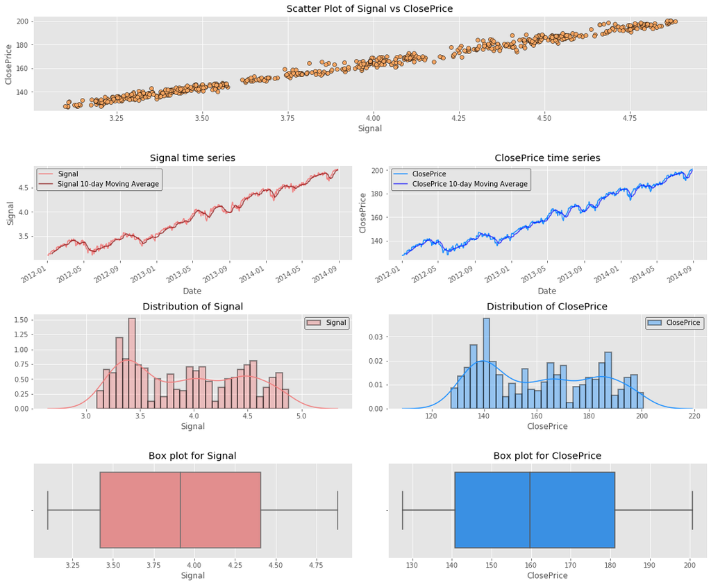

```python
plots_for_outliers(clean_data)
```

> **Comment:**
> - Scatter plot clearly shows a linear relationship between `Signal` and `ClosePrice` after removing the outliers.
> - Individual time-series plots also looks good.
> - Box plot for both the series shows a clear interquartile range with min and max values highlighted.
> - Our data is clean now and ready for analysis.

# Correlation between Signal and ClosePrice

```python
# Pearson correlation metric using scipy stats function
r, p = stats.pearsonr(clean_data['Signal'], clean_data['ClosePrice'])
print(f"Pearson correlation: {r} and p-value: {p}" )
```

```
Pearson correlation: 0.9951522918139974 and p-value: 0.0
```

```python
# Pearson correlation metric using pandas.corr() matrix
clean_data.corr(method='pearson')
```

|  | Signal | ClosePrice |
| --- | --- | --- |
| Signal | 1.000000 | 0.995152 |
| ClosePrice | 0.995152 | 1.000000 |

# Relationship between Signal and ClosePrice

From the scatter plot, we know there exists a linear relationship between `Signal` and `ClosePrice`. But we need to also check whether there exists any relationship between `Signal` and `ClosePrice` at different lags (if any for both the series).

To achieve this, we calculate cross-correlation between the two time-series for different lags and plot it.

```python
def plots_for_relationship(df):
    """
    Useful plots for checking relationship (via correlation) for two time-series
    """
    signal = df['Signal']
    close_price = df['ClosePrice']

    grid = gridspec.GridSpec(nrows=2, ncols=1)

    fig = plt.figure(figsize=(15, 7))
    fig.clf()

    # Add axes which can span multiple grid boxes
    ax1 = fig.add_subplot(grid[0, :])
    ax2 = fig.add_subplot(grid[1, :])

    # Cross correlation plot
    cross_correlation_plot(df, x='Signal', y='ClosePrice', ax=ax1)

    # Rolling correlation plots
    rolling_correlation_plot(df=df, ax=ax2)

    fig.tight_layout()
    plt.show()
```

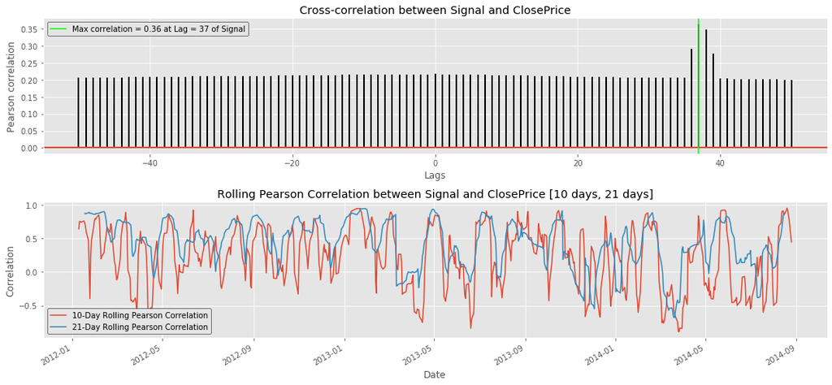

```python
plots_for_relationship(data)
```

> **Comment:**
> - With data including outliers, the highest correlation value of 0.36 between `Signal` and `ClosePrice` is obtained at Lag 37 of `Signal`

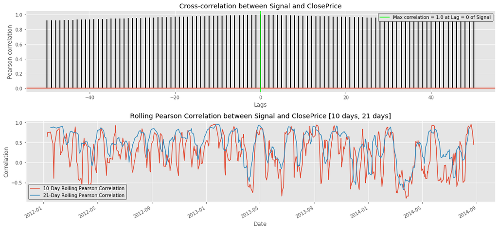

```python
plots_for_relationship(clean_data)
```

> **Comment:**
> - With data that replaced outliers by interpolated values, the highest correlation value of 1.0 between `Signal` and `ClosePrice` is obtained at Lag 0 of `Signal`

# Modeling

Since there exists a linear relationship between `Signal` and `ClosePrice` after cleaning the data (i.e. from the earlier plots), let's apply simple linear regression to see if our independent variable `Signal` helps us to predict dependent variable `ClosePrice` of SPY.

```python
def linear_regression(df, y_col, x_col=None, plot=False):
    """
    Perform linear regression and plot the regression line.
    """
    x_cols = []

    if x_col is None:
        # If multiple regression, add all columns except y as X-variables
        x_cols = [col for col in df.columns if col != y_col]
    else:
        # Simple linear regression with just 1 independent variable
        x_cols = [x_col]

    # adding a intercept to X
    X = sm.add_constant(df[x_cols])
    Y = df[y_col]

    model = sm.OLS(Y, X).fit()
    print_model = model.summary()
    print(print_model)

    # Line of best fit
    if plot:
        fig, ax = plt.subplots(figsize=(15, 10))
        clean_data.plot(x=x_col, y=y_col, kind='scatter', ax=ax, label='Data Points')
        abline_plot(model_results=model, ax=ax, label='Fitted line')
        ax.set(title='Line of best-fit for Signal vs ClosePrice',
               xlabel=x_col,
               ylabel=y_col)
        add_legend(ax)

        plt.show()

    return model
```

```
                            OLS Regression Results
==============================================================================
Dep. Variable:             ClosePrice   R-squared:                       0.990
Model:                            OLS   Adj. R-squared:                  0.990
Method:                 Least Squares   F-statistic:                 6.789e+04
Date:                Thu, 06 Feb 2020   Prob (F-statistic):               0.00
Time:                        23:06:25   Log-Likelihood:                -1439.1
No. Observations:                 665   AIC:                             2882.
Df Residuals:                     663   BIC:                             2891.
Df Model:                           1
Covariance Type:            nonrobust
==============================================================================
                 coef    std err          t      P>|t|      [0.025      0.975]
------------------------------------------------------------------------------
const          1.6529      0.617      2.679      0.008       0.442       2.864
Signal        40.6862      0.156    260.549      0.000      40.380      40.993
==============================================================================
Omnibus:                       32.061   Durbin-Watson:                   0.643
Prob(Omnibus):                  0.000   Jarque-Bera (JB):               53.880
Skew:                           0.356   Prob(JB):                     2.00e-12
Kurtosis:                       4.199   Cond. No.                         31.7
==============================================================================

Warnings:
[1] Standard Errors assume that the covariance matrix of the errors is correctly specified.
```

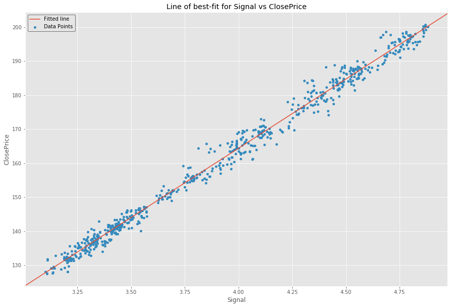

```python
model = linear_regression(clean_data, x_col='Signal', y_col='ClosePrice', plot=True)
```

# Quality Check of Model

Quality check of our fitted model is very important to check if the fitted model does not violate the assumptions behind this simple linear model.

These assumptions are:

1. Linear relationship between independent and dependent variable
2. Gauss-Markov Theorem: OLS estimator gives the best linear unbiased estimate (BLUE) of the coefficients, given:
   - Mean or Expectation of error (residuals) is 0
   - Errors are uncorrelated
   - Errors are homoscedastic (i.e. they have equal variance)
3. Independent variables and residuals are uncorrelated
4. Normality of residuals

Let's verify if these assumptions are not violated one-by-one.

## Linear relationship

> **Comment:**
> - Linear relationship is clearly seen from the scatter plot of `Signal` against `ClosePrice`.

## Mean of residuals should be 0

```python
np.mean(model.resid)
```

```
-1.3676612056735762e-14
```

> **Comment:**
> - Mean of residual is very small (approximately equal to 0). So this assumption is not violated.

## Residuals are homoscedastic

To check if residuals are homoscedastic, we can look at the plot of residuals vs predicted (fitted) values and perform Breusch-Pagan test.

### Residual vs Fitted values plot

```python
def homoscedastic_plot(model):
    """
    Plot for homoscedasticity check
    """
    fitted_values = model.predict()
    residuals = model.resid
    residuals_standardized = model.get_influence().resid_studentized_internal

    fig, ax = plt.subplots(1, 2, figsize=(15, 7))

    sns.regplot(x=fitted_values, y=residuals, lowess=True, ax=ax[0], line_kws={'color': 'red'})
    ax[0].set(title='Residuals vs Fitted',
              xlabel='Fitted Values',
              ylabel='Residuals')

    sns.regplot(x=fitted_values, y=np.sqrt(np.abs(residuals_standardized)), lowess=True, ax=ax[1], line_kws={'color': 'red'})
    ax[1].set(title='Scale-Location',
              xlabel='Fitted Values',
              ylabel='sqrt[abs(residuals)]')

    fig.tight_layout()
    plt.show()
```

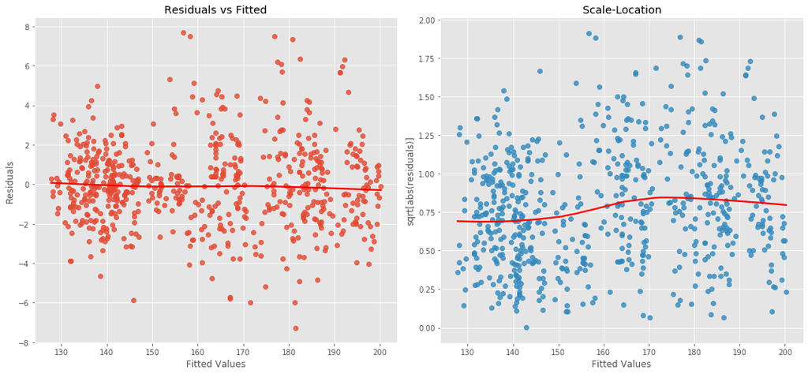

```python
homoscedastic_plot(model)
```

### Breusch-Pagan Test

Breusch-Pagan test creates a statistic that is chi-squared distributed. p-value is the result of the chi-squared test and null hypothesis of homoscedasticity is rejected if p-value < 0.05

```python
bp = pd.DataFrame(columns=['Values'], index=['Lagrange multiplier statistic', 'p-value', 'f-value', 'f p-value'])
bp['Values'] = sms.het_breuschpagan(model.resid, model.model.exog)
bp
```

|  | Values |
| --- | --- |
| Lagrange multiplier statistic | 14.422804 |
| p-value | 0.000146 |
| f-value | 14.698209 |
| f p-value | 0.000138 |

## Residuals are uncorrelated

Residuals should be uncorrelated. We can test it by plotting ACF (auto correlation function) plot and Durbin-Watson test.

### Plotting Autocorrelation Function

```python
def plot_acf(model):
    """
    Plot autocorrelation function
    """
    fig, ax = plt.subplots(figsize=(15, 7))
    acf = smt.graphics.plot_acf(model.resid, lags=50, alpha=0.05, ax=ax)
    acf.show()
```

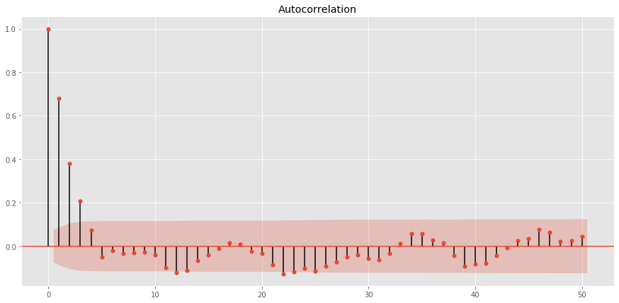

```python
plot_acf(model)
```

> **Comment:**
> - ACF plot shows significant correlation at lags 1, 2 and 3. Thus it indicates the presence of positive serial autocorrelation.

### Durbin-Watson Test

This test statistic is used to detect the presence of autocorrelation at lag 1 in the residuals. Value of the test statistic is always between 0 and 4. If the value is 2, then there is no autocorrelation. If value < 2, then positive autocorrelation in residuals. If value > 2, negative autocorrelation in residuals exists.

```python
model.summary()
```

OLS Regression Results

| Dep. Variable: | ClosePrice | R-squared: | 0.990 |
| --- | --- | --- | --- |
| Model: | OLS | Adj. R-squared: | 0.990 |
| Method: | Least Squares | F-statistic: | 6.789e+04 |
| Date: | Thu, 06 Feb 2020 | Prob (F-statistic): | 0.00 |
| Time: | 23:17:50 | Log-Likelihood: | -1439.1 |
| No. Observations: | 665 | AIC: | 2882. |
| Df Residuals: | 663 | BIC: | 2891. |
| Df Model: | 1 |  |  |
| Covariance Type: | nonrobust |  |  |

|  | coef | std err | t | P>\|t\| | [0.025 | 0.975] |
| --- | --- | --- | --- | --- | --- | --- |
| const | 1.6529 | 0.617 | 2.679 | 0.008 | 0.442 | 2.864 |
| Signal | 40.6862 | 0.156 | 260.549 | 0.000 | 40.380 | 40.993 |

| Omnibus: | 32.061 | Durbin-Watson: | 0.643 |
| --- | --- | --- | --- |
| Prob(Omnibus): | 0.000 | Jarque-Bera (JB): | 53.880 |
| Skew: | 0.356 | Prob(JB): | 2.00e-12 |
| Kurtosis: | 4.199 | Cond. No. | 31.7 |

Warnings:  
[1] Standard Errors assume that the covariance matrix of the errors is correctly specified.

> **Comment:**
> - Durbin-Watson test value of 0.643 from the above summary shows that there is some positive autocorrelation (value < 2) in the residuals

### Fix

Some of the ways to fix the serial autocorrelation problem of residuals are:

> **Comment:**
> - Add more lagged terms in the independent variables
> - Stationarize the time-series by differencing, taking logs etc.
> - Use Generalized Least Squares

## Independent variable and residuals are uncorrelated

```python
correlation, p_value = stats.pearsonr(model.resid, model.model.endog)
print("Correlation between Signal column and residuals of model is {0:.4f} and corresponding p-value is {1:.3f}".format(correlation, p_value))
```

[output not shown]

## Normality test of residuals

```python
def qqplot(model):
    """
    QQ plot for residuals
    """
    fig, ax = plt.subplots(figsize=(10, 10))
    sm.ProbPlot(model.resid).qqplot(line='s', ax=ax)
    plt.show()
```

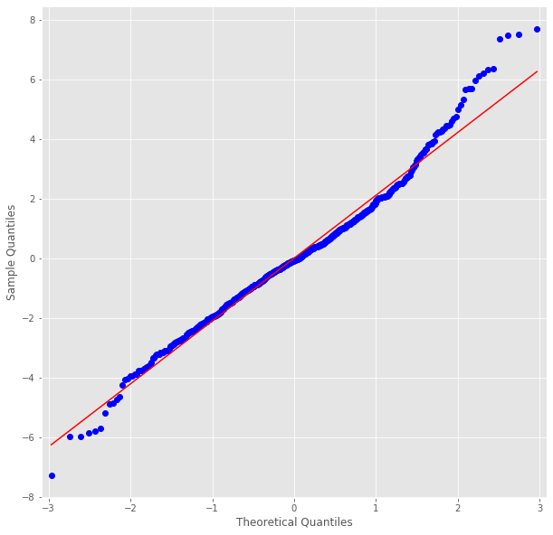

```python
qqplot(model)
```

> **Comment:**
> - QQ-plot shows that residuals do not lie on the red-line and deviate from it at the ends. Thus the residuals do not follow Gaussian distribution.

### Jarque-Barra test

```python
jb = stats.jarque_bera(model.resid)
print("Jarque-Barra test for normality of residuals: ")
print("Statistics: {0} and p-value: {1}".format(jb[0], jb[1]))
```

```
Jarque-Barra test for normality of residuals:
Statistics: 53.88044621856731 and p-value: 1.9952928198563313e-12
```

> **Comment:**
> - p-value is very low (<<< 0.05), thus we can reject the null hypothesis that residuals are normally distributed.

### Fixes

Some of the ways to fix the normality of residuals problem:

> **Comment:**
> - Current Model does not correctly/fully explain the data. We need to come up with a good enough model that can fully explain the data.

# Conclusion

> **To conclude:**
> - Despite `Signal` being a statistical significant predictor of `ClosePrice`, some of the assumptions of the linear model are violated and thus current model does not fully explain the data.
> - Newer model must overcome the shortcomings of our current model and ensure assumptions are satisfied (adding lagged variables, transforming the features, differencing of feature values, taking log, using Generalized Least Squares etc)

# Future Work:

## Feature Engineering

Feature engineering is a very important step in building a predictive machine learning model. Identifying the right set of features can help the model to perform better and higher accuracy.

Features can be added to our data using following:

- Add datetime based features
- Add technical indicators as features of Signal value such as Relative Strength Index, Simple Moving Average, Exponential Moving Average etc.
- Add lags/windowed values (mean, std etc.) of Signal value

### DateTime-based features

```python
def add_datetime_features(df):
    """
    Add features based on datetime index.
    """
    _df = df.copy()

    if not isinstance(_df.index, pd.DatetimeIndex):
        _df.index = pd.to_datetime(_df.index)

    # Add year, quarter, month, week, day
    _df['Year'] = _df.index.year
    _df['Quarter'] = _df.index.quarter
    _df['Month'] = _df.index.month
    _df['Week'] = _df.index.week
    _df['Day'] = _df.index.day

    # Add day of week
    _df['DayofWeek'] = _df.index.dayofweek

    return _df
```

```python
clean_data_with_features = add_datetime_features(clean_data)
clean_data_with_features
```

[output not shown]

### Technical Indicators

More technical features can be added to build a predictive machine learning model

- Simple Moving Average
- Exponential Moving Average
- Relative Strength Index
- Moving Average Convergence Divergence (MACD) etc.

### Lagged Features

Lagged features include

- Adding lag terms for `Signal` at different lag levels etc.

## Advanced Machine Learning Models

Once features are built, we can test various advanced machine learning models such as

- Decision Trees & Random Forest
- XGBoost (type of Gradient Boosting)
- LightGBM (type of Gradient Boosting)
- LSTM (Long Short-Term Memory - a type of recurrent neural network)

to predict the SPY prices.